# Checkbox functions

# 1 Generate data

```r
set.seed(100)
trib.x <- tibble::tribble(
   ~nv,     ~check,
   "1",    "Mouse",
   "2",      "Rat",
   "3",      "Cat",
   "4",      "Dog",
   "5",   "Donkey",
   "6",   "Monkey",
   "7",   "Turtle",
   "8", "Hedgehog",
   "9", "Blue jay",
  "10",    "Rhino",
  "11",    "Other",
  "12",     "None")


# check_data("10") %>% jgtt()
#
# check_data_repeat(10, 5)

X <- data.frame(id = 1:100, rep = sample(1:6, 100, replace = TRUE))

c1 <- map(X$id, .f = check_data) %>% bind_rows()%>%
  left_join(., trib.x, by = "nv") %>%
  mutate(checkbox = paste(checkbox, nv, sep = "_"), check = ifelse(x==1, check, NA)) %>%
  select(-x, -nv) %>%
  pivot_wider(., names_from = "checkbox", values_from = "check", values_fill = NA)


cb <- map2(.x = X$id, .y = X$rep, .f = check_data_repeat) %>% bind_rows()%>%
  left_join(., trib.x, by = "nv") %>%
  mutate(checkbox = paste(checkbox, nv, sep = "_"), check = ifelse(x==1, check, NA)) %>%
  select(-x, -nv) %>%
  pivot_wider(., names_from = "checkbox", values_from = "check", values_fill = NA)


# j.label4(cb, collect.labels(df))
cb <- set_label( cb ,
 id = 'ID',
 rri = 'Repeat instance',
 site = 'Site',
 checkbox_1 = 'Mouse',
 checkbox_2 = 'Rat',
 checkbox_3 = 'Cat',
 checkbox_4 = 'Dog',
 checkbox_5 = 'Donkey',
 checkbox_6 = 'Monkey',
 checkbox_7 = 'Turtle',
 checkbox_8 = 'Hedgehog',
 checkbox_9 = 'Blue jay',
 checkbox_10 = 'Rhino',
 checkbox_11 = 'Other',
 checkbox_12 = 'None')

cb %<>% clear.label.class()

c1 <- set_label( c1 ,
 id = 'ID',
 site = 'Site',
 checkbox_1 =  'What animals did you see? (choice=Mouse)',
 checkbox_2 =  'What animals did you see? (choice=Rat)',
 checkbox_3 =  'What animals did you see? (choice=Cat)',
 checkbox_4 =  'What animals did you see? (choice=Dog)',
 checkbox_5 =  'What animals did you see? (choice=Donkey)',
 checkbox_6 =  'What animals did you see? (choice=Monkey)',
 checkbox_7 =  'What animals did you see? (choice=Turtle)',
 checkbox_8 =  'What animals did you see? (choice=Hedgehog)',
 checkbox_9 =  'What animals did you see? (choice=Blue jay)',
 checkbox_10 = 'What animals did you see? (choice=Rhino)',
 checkbox_11 = 'What animals did you see? (choice=Other)',
 checkbox_12 = 'What animals did you see? (choice=None)')

c1 %<>% clear.label.class()

c2 <- set_label( c1 ,
 id = 'ID',
 site = 'Site',
 checkbox_1 =  'Some string that does not fit the pattern: Mouse',
 checkbox_2 =  'Some string that does not fit the pattern: Rat',
 checkbox_3 =  'Some string that does not fit the pattern: Cat',
 checkbox_4 =  'Some string that does not fit the pattern: Dog',
 checkbox_5 =  'Some string that does not fit the pattern: Donkey',
 checkbox_6 =  'Some string that does not fit the pattern: Monkey',
 checkbox_7 =  'Some string that does not fit the pattern: Turtle',
 checkbox_8 =  'Some string that does not fit the pattern: Hedgehog',
 checkbox_9 =  'Some string that does not fit the pattern: Blue jay',
 checkbox_10 = 'Some string that does not fit the pattern: Rhino',
 checkbox_11 = 'Some string that does not fit the pattern: Other',
 checkbox_12 = 'Some string that does not fit the pattern: None')

c2 %<>% clear.label.class()
```

## 1.1 simple checkbox data

```r
c1 %>% clear.labels() %>% head(10) %>% jgtt(., col.names = FALSE)
```

| id | site | checkbox_1 | checkbox_2 | checkbox_3 | checkbox_4 | checkbox_5 | checkbox_6 | checkbox_7 | checkbox_8 | checkbox_9 | checkbox_10 | checkbox_11 | checkbox_12 |
| --- | --- | --- | --- | --- | --- | --- | --- | --- | --- | --- | --- | --- | --- |
| 1 | Site B | NA | NA | NA | NA | NA | NA | NA | NA | Blue jay | NA | NA | None |
| 2 | Site B | NA | NA | NA | Dog | NA | NA | NA | Hedgehog | Blue jay | NA | NA | NA |
| 3 | Site B | NA | NA | NA | NA | NA | NA | NA | NA | Blue jay | NA | NA | NA |
| 4 | Site A | NA | NA | Cat | NA | NA | NA | NA | NA | Blue jay | NA | NA | NA |
| 5 | Site A | NA | NA | Cat | Dog | NA | NA | Turtle | NA | NA | NA | NA | NA |
| 6 | Site A | NA | Rat | Cat | Dog | NA | Monkey | Turtle | NA | NA | NA | NA | NA |
| 7 | Site B | NA | NA | NA | Dog | NA | NA | NA | NA | NA | NA | Other | NA |
| 8 | Site B | NA | NA | NA | NA | NA | NA | Turtle | NA | NA | NA | NA | NA |
| 9 | Site A | NA | NA | NA | NA | NA | NA | NA | NA | NA | NA | NA | NA |
| 10 | Site B | NA | NA | Cat | Dog | NA | NA | NA | NA | NA | Rhino | NA | NA |

## 1.2 repeating checkbox

```r
cb %>% clear.labels() %>% head(10) %>% jgtt(., col.names = FALSE)
```

| id | site | rri | checkbox_1 | checkbox_2 | checkbox_3 | checkbox_4 | checkbox_5 | checkbox_6 | checkbox_7 | checkbox_8 | checkbox_9 | checkbox_10 | checkbox_11 | checkbox_12 |
| --- | --- | --- | --- | --- | --- | --- | --- | --- | --- | --- | --- | --- | --- | --- |
| 1 | Site B | 1 | Mouse | NA | NA | Dog | NA | Monkey | Turtle | NA | NA | NA | Other | NA |
| 1 | Site B | 2 | Mouse | Rat | NA | NA | NA | NA | NA | Hedgehog | NA | NA | NA | NA |
| 2 | Site B | 1 | Mouse | NA | NA | NA | NA | NA | NA | NA | Blue jay | Rhino | NA | NA |
| 2 | Site B | 2 | NA | NA | Cat | Dog | Donkey | NA | NA | NA | NA | NA | NA | NA |
| 2 | Site B | 3 | NA | NA | Cat | NA | NA | Monkey | NA | NA | NA | NA | NA | NA |
| 2 | Site B | 4 | NA | NA | NA | NA | NA | NA | NA | NA | NA | NA | NA | NA |
| 2 | Site B | 5 | Mouse | NA | NA | NA | NA | Monkey | Turtle | NA | NA | NA | Other | NA |
| 2 | Site B | 6 | NA | NA | Cat | NA | NA | Monkey | NA | NA | NA | NA | NA | None |
| 3 | Site B | 1 | NA | NA | NA | NA | NA | NA | NA | Hedgehog | NA | Rhino | NA | None |
| 3 | Site B | 2 | NA | NA | NA | NA | NA | NA | Turtle | NA | NA | NA | NA | None |

# 2 checkbox_gather

## 2.1 Simple checkbox data

### 2.1.1 Data frame output

Returns data frame that can be joined to original data. Columns may be more suited to other summary tables or modeling.

```r
checkbox_gather(c1, selection = "checkbox", id.var = c("id")) %>% head()%>% jgtt()
```

| id | any_checkbox_1 | any_checkbox_2 | any_checkbox_3 | any_checkbox_4 | any_checkbox_5 | any_checkbox_6 | any_checkbox_7 | any_checkbox_8 | any_checkbox_9 | any_checkbox_10 | any_checkbox_11 | any_checkbox_12 |
| --- | --- | --- | --- | --- | --- | --- | --- | --- | --- | --- | --- | --- |
| 1 | No | No | No | No | No | No | No | No | Yes | No | No | Yes |
| 2 | No | No | No | Yes | No | No | No | Yes | Yes | No | No | No |
| 3 | No | No | No | No | No | No | No | No | Yes | No | No | No |
| 4 | No | No | Yes | No | No | No | No | No | Yes | No | No | No |
| 5 | No | No | Yes | Yes | No | No | Yes | No | No | No | No | No |
| 6 | No | Yes | Yes | Yes | No | Yes | Yes | No | No | No | No | No |

### 2.1.2 Change data type

With non-repeating data, ‘any’ and ‘total’ are equivalent. However, setting `count = "total"` returns numeric columns.

```r
checkbox_gather(c1, selection = "checkbox", id.var = c("id"), count = "total")%>%head() %>% jgtt()
```

| id | total_checkbox_1 | total_checkbox_2 | total_checkbox_3 | total_checkbox_4 | total_checkbox_5 | total_checkbox_6 | total_checkbox_7 | total_checkbox_8 | total_checkbox_9 | total_checkbox_10 | total_checkbox_11 | total_checkbox_12 |
| --- | --- | --- | --- | --- | --- | --- | --- | --- | --- | --- | --- | --- |
| 1 | 0 | 0 | 0 | 0 | 0 | 0 | 0 | 0 | 1 | 0 | 0 | 1 |
| 2 | 0 | 0 | 0 | 1 | 0 | 0 | 0 | 1 | 1 | 0 | 0 | 0 |
| 3 | 0 | 0 | 0 | 0 | 0 | 0 | 0 | 0 | 1 | 0 | 0 | 0 |
| 4 | 0 | 0 | 1 | 0 | 0 | 0 | 0 | 0 | 1 | 0 | 0 | 0 |
| 5 | 0 | 0 | 1 | 1 | 0 | 0 | 1 | 0 | 0 | 0 | 0 | 0 |
| 6 | 0 | 1 | 1 | 1 | 0 | 1 | 1 | 0 | 0 | 0 | 0 | 0 |

### 2.1.3 Summary output

Checkboxes are non-mutually exclusive, so percentages will not sum to 100%.

**Interpretation:** 20 people included checkbox_1 among their selections.

```r
checkbox_gather(c1, selection = "checkbox", id.var = c("id"), output = "summary")
```

| **Characteristic** | **N = 100**<sup>1</sup> |
| --- | --- |
| any_checkbox_1 | 20 (20.0%) |
| any_checkbox_2 | 21 (21.0%) |
| any_checkbox_3 | 27 (27.0%) |
| any_checkbox_4 | 22 (22.0%) |
| any_checkbox_5 | 18 (18.0%) |
| any_checkbox_6 | 22 (22.0%) |
| any_checkbox_7 | 18 (18.0%) |
| any_checkbox_8 | 19 (19.0%) |
| any_checkbox_9 | 27 (27.0%) |
| any_checkbox_10 | 24 (24.0%) |
| any_checkbox_11 | 16 (16.0%) |
| any_checkbox_12 | 10 (10.0%) |

<sup>1</sup> n (%)

### 2.1.4 Account for no selections made

Even if there is a checkbox specifically for “none” or “none of the above”, there is still room for data entry errors. Setting `add.zero = TRUE` will append a new row to the data, and anyone with no other selections will be counted here.

**Interpretation:** 4 people had zero boxes selected.

```r
checkbox_gather(c1, selection = "checkbox", id.var = c("id"), output = "summary",
                add.zero = TRUE)
```

| **Characteristic** | **N = 100**<sup>1</sup> |
| --- | --- |
| any_checkbox_1 | 20 (20.0%) |
| any_checkbox_2 | 21 (21.0%) |
| any_checkbox_3 | 27 (27.0%) |
| any_checkbox_4 | 22 (22.0%) |
| any_checkbox_5 | 18 (18.0%) |
| any_checkbox_6 | 22 (22.0%) |
| any_checkbox_7 | 18 (18.0%) |
| any_checkbox_8 | 19 (19.0%) |
| any_checkbox_9 | 27 (27.0%) |
| any_checkbox_10 | 24 (24.0%) |
| any_checkbox_11 | 16 (16.0%) |
| any_checkbox_12 | 10 (10.0%) |
| any_checkbox_zero | 4 (4.00%) |

<sup>1</sup> n (%)

### 2.1.5 Add variable labels

Setting `toggle.names = TRUE` will use the variable labels rather than the variable names.

```r
checkbox_gather(c1, selection = "checkbox", id.var = c("id"), output = "summary",
                add.zero = TRUE, toggle.names = TRUE)
```

| **Characteristic** | **N = 100**<sup>1</sup> |
| --- | --- |
| What animals did you see? (choice=Mouse) (any) | 20 (20.0%) |
| What animals did you see? (choice=Rat) (any) | 21 (21.0%) |
| What animals did you see? (choice=Cat) (any) | 27 (27.0%) |
| What animals did you see? (choice=Dog) (any) | 22 (22.0%) |
| What animals did you see? (choice=Donkey) (any) | 18 (18.0%) |
| What animals did you see? (choice=Monkey) (any) | 22 (22.0%) |
| What animals did you see? (choice=Turtle) (any) | 18 (18.0%) |
| What animals did you see? (choice=Hedgehog) (any) | 19 (19.0%) |
| What animals did you see? (choice=Blue jay) (any) | 27 (27.0%) |
| What animals did you see? (choice=Rhino) (any) | 24 (24.0%) |
| What animals did you see? (choice=Other) (any) | 16 (16.0%) |
| What animals did you see? (choice=None) (any) | 10 (10.0%) |
| [Zero selected] (any) | 4 (4.00%) |

<sup>1</sup> n (%)

### 2.1.6 Remove trailing description

Changing `simple.names = TRUE` will clean up the trailing descriptor. Note, this feature does not work if `count = "both"`.

```r
checkbox_gather(c1, selection = "checkbox", id.var = c("id"), output = "summary",
                add.zero = TRUE, toggle.names = TRUE, simple.names = TRUE)
```

| **Characteristic** | **N = 100**<sup>1</sup> |
| --- | --- |
| What animals did you see? (choice=Mouse) | 20 (20.0%) |
| What animals did you see? (choice=Rat) | 21 (21.0%) |
| What animals did you see? (choice=Cat) | 27 (27.0%) |
| What animals did you see? (choice=Dog) | 22 (22.0%) |
| What animals did you see? (choice=Donkey) | 18 (18.0%) |
| What animals did you see? (choice=Monkey) | 22 (22.0%) |
| What animals did you see? (choice=Turtle) | 18 (18.0%) |
| What animals did you see? (choice=Hedgehog) | 19 (19.0%) |
| What animals did you see? (choice=Blue jay) | 27 (27.0%) |
| What animals did you see? (choice=Rhino) | 24 (24.0%) |
| What animals did you see? (choice=Other) | 16 (16.0%) |
| What animals did you see? (choice=None) | 10 (10.0%) |
| [Zero selected] | 4 (4.00%) |

<sup>1</sup> n (%)

### 2.1.7 Clean up labels

Often redcap variable labels for checkboxes contain a lot of extraneous information. Adjusting `tidy.labels = TRUE` should fix this assuming the pattern is of “Long description (choice=**DATA ITEM**)”

```r
checkbox_gather(c1, selection = "checkbox", id.var = c("id"), output = "summary",
                add.zero = TRUE, toggle.names = TRUE, simple.names = TRUE,
                tidy.labels = TRUE)
```

| **Characteristic** | **N = 100**<sup>1</sup> |
| --- | --- |
| Mouse | 20 (20.0%) |
| Rat | 21 (21.0%) |
| Cat | 27 (27.0%) |
| Dog | 22 (22.0%) |
| Donkey | 18 (18.0%) |
| Monkey | 22 (22.0%) |
| Turtle | 18 (18.0%) |
| Hedgehog | 19 (19.0%) |
| Blue jay | 27 (27.0%) |
| Rhino | 24 (24.0%) |
| Other | 16 (16.0%) |
| None | 10 (10.0%) |
| [Zero selected] | 4 (4.00%) |

<sup>1</sup> n (%)

#### 2.1.7.1 Labels that don’t fit pattern

If the label pattern is not consistent with the above, setting `tidy.labels = TRUE` will yield the following:

```r
checkbox_gather(c2, selection = "checkbox", id.var = c("id"), output = "summary",
                add.zero = TRUE, toggle.names = TRUE, simple.names = TRUE,
                tidy.labels = TRUE)
```

| **Characteristic** | **N = 100**<sup>1</sup> |
| --- | --- |
| Some string that does not fit the pattern: Mous | 20 (20.0%) |
| Some string that does not fit the pattern: Ra | 21 (21.0%) |
| Some string that does not fit the pattern: Ca | 27 (27.0%) |
| Some string that does not fit the pattern: Do | 22 (22.0%) |
| Some string that does not fit the pattern: Donke | 18 (18.0%) |
| Some string that does not fit the pattern: Monke | 22 (22.0%) |
| Some string that does not fit the pattern: Turtl | 18 (18.0%) |
| Some string that does not fit the pattern: Hedgeho | 19 (19.0%) |
| Some string that does not fit the pattern: Blue ja | 27 (27.0%) |
| Some string that does not fit the pattern: Rhin | 24 (24.0%) |
| Some string that does not fit the pattern: Othe | 16 (16.0%) |
| Some string that does not fit the pattern: Non | 10 (10.0%) |
| [Zero selected] | 4 (4.00%) |

<sup>1</sup> n (%)

Utilize the `str.rm` argument by passing the exact string you want removed. This utilizes regular expressions via `gsub`.

```r
checkbox_gather(c2, selection = "checkbox", id.var = c("id"), output = "summary",
                add.zero = TRUE, toggle.names = TRUE, simple.names = TRUE,
                str.rm = "Some string that does not fit the pattern: ",
                tidy.labels = TRUE)
```

| **Characteristic** | **N = 100**<sup>1</sup> |
| --- | --- |
| Mouse | 20 (20.0%) |
| Rat | 21 (21.0%) |
| Cat | 27 (27.0%) |
| Dog | 22 (22.0%) |
| Donkey | 18 (18.0%) |
| Monkey | 22 (22.0%) |
| Turtle | 18 (18.0%) |
| Hedgehog | 19 (19.0%) |
| Blue jay | 27 (27.0%) |
| Rhino | 24 (24.0%) |
| Other | 16 (16.0%) |
| None | 10 (10.0%) |
| [Zero selected] | 4 (4.00%) |

<sup>1</sup> n (%)

### 2.1.8 Order fields by frequency

```r
checkbox_gather(c1, selection = "checkbox", id.var = c("id"), output = "summary",
                add.zero = TRUE, toggle.names = TRUE, simple.names = TRUE,
                reorder.cols = TRUE,
                tidy.labels = TRUE)
```

| **Characteristic** | **N = 100**<sup>1</sup> |
| --- | --- |
| Cat | 27 (27.0%) |
| Blue jay | 27 (27.0%) |
| Rhino | 24 (24.0%) |
| Dog | 22 (22.0%) |
| Monkey | 22 (22.0%) |
| Rat | 21 (21.0%) |
| Mouse | 20 (20.0%) |
| Hedgehog | 19 (19.0%) |
| Donkey | 18 (18.0%) |
| Turtle | 18 (18.0%) |
| Other | 16 (16.0%) |
| None | 10 (10.0%) |
| [Zero selected] | 4 (4.00%) |

<sup>1</sup> n (%)

### 2.1.9 Report checkbox stats

An alternative to individual checkbox summaries is aggregated summaries. For non-repeating data, setting `stats` to `only` will present the number of zero selections as well as the total number of selections each participant made.

**Interpretation:** 11 participants made 4 selections, while 22 participants only reported one each.

```r
checkbox_gather(c1, selection = "checkbox", id.var = c("id"),
                stats = "only", toggle.names = TRUE, output = "summary")
```

| **Characteristic** | **N = 100**<sup>1</sup> |
| --- | --- |
| No selections made across all observations | 4 (4.00%) |
| Number of selections made |  |
| 0 | 4 (4.00%) |
| 1 | 22 (22.0%) |
| 2 | 28 (28.0%) |
| 3 | 28 (28.0%) |
| 4 | 11 (11.0%) |
| 5 | 4 (4.00%) |
| 6 | 3 (3.00%) |

<sup>1</sup> n (%)

### 2.1.10 Add in stratafication variable

Summaries can be stratified by putting the desired variable at `by.var = "site"`.

**Interpretation:** 7 people at site A and 4 people at site B reported seeing 4 animals.

```r
checkbox_gather(c1, selection = "checkbox", id.var = c("id"),  by.var = "site",
                stats = "only", toggle.names = TRUE, output = "summary")
```

| **Characteristic** | **Site A**, N = 38<sup>1</sup> | **Site B**, N = 62<sup>1</sup> | **Overall**, N = 100<sup>1</sup> |
| --- | --- | --- | --- |
| No selections made across all observations | 1 (2.63%) | 3 (4.84%) | 4 (4.00%) |
| Number of selections made |  |  |  |
| 0 | 1 (2.63%) | 3 (4.84%) | 4 (4.00%) |
| 1 | 10 (26.3%) | 12 (19.4%) | 22 (22.0%) |
| 2 | 12 (31.6%) | 16 (25.8%) | 28 (28.0%) |
| 3 | 7 (18.4%) | 21 (33.9%) | 28 (28.0%) |
| 4 | 7 (18.4%) | 4 (6.45%) | 11 (11.0%) |
| 5 | 1 (2.63%) | 3 (4.84%) | 4 (4.00%) |
| 6 | 0 (0%) | 3 (4.84%) | 3 (3.00%) |

<sup>1</sup> n (%)

## 2.2 Repeating data - record level

To produce summaries on the record (ID) level using repeating data, simply leave `repeat.var = NULL`

### 2.2.1 Count any

**Interpretation:** 33 people reported seeing a mouse at least once at site A.

```r
checkbox_gather(cb, selection = "checkbox", id.var = c("id"),
                by.var = "site", simple.names = FALSE,
                count = "any", stats = "none", toggle.names = TRUE, add.zero = TRUE, output = "summary")
```

| **Characteristic** | **Site A**, N = 60<sup>1</sup> | **Site B**, N = 40<sup>1</sup> | **Overall**, N = 100<sup>1</sup> |
| --- | --- | --- | --- |
| Mouse (any) | 33 (55.0%) | 23 (57.5%) | 56 (56.0%) |
| Rat (any) | 29 (48.3%) | 23 (57.5%) | 52 (52.0%) |
| Cat (any) | 30 (50.0%) | 20 (50.0%) | 50 (50.0%) |
| Dog (any) | 34 (56.7%) | 24 (60.0%) | 58 (58.0%) |
| Donkey (any) | 36 (60.0%) | 20 (50.0%) | 56 (56.0%) |
| Monkey (any) | 29 (48.3%) | 16 (40.0%) | 45 (45.0%) |
| Turtle (any) | 33 (55.0%) | 25 (62.5%) | 58 (58.0%) |
| Hedgehog (any) | 34 (56.7%) | 17 (42.5%) | 51 (51.0%) |
| Blue jay (any) | 34 (56.7%) | 12 (30.0%) | 46 (46.0%) |
| Rhino (any) | 35 (58.3%) | 18 (45.0%) | 53 (53.0%) |
| Other (any) | 28 (46.7%) | 29 (72.5%) | 57 (57.0%) |
| None (any) | 33 (55.0%) | 16 (40.0%) | 49 (49.0%) |
| [Zero selected] (any) | 13 (21.7%) | 8 (20.0%) | 21 (21.0%) |

<sup>1</sup> n (%)

### 2.2.2 Count total

**Interpretation:** At site A, 17 people reported seeing 1 mouse, 14 saw 2 mice and 2 people saw 3 mice. (17 + 14 + 2 = 33, which matches the `count = "any"` output above.)

```r
checkbox_gather(cb, selection = "checkbox", id.var = c("id"),
                by.var = "site", simple.names = FALSE,
                count = "total", stats = "none", toggle.names = TRUE, add.zero = TRUE, output = "summary")
```

| **Characteristic** | **Site A**, N = 60<sup>1</sup> | **Site B**, N = 40<sup>1</sup> | **Overall**, N = 100<sup>1</sup> |
| --- | --- | --- | --- |
| Mouse (total) |  |  |  |
| 0 | 27 (45.0%) | 17 (42.5%) | 44 (44.0%) |
| 1 | 17 (28.3%) | 15 (37.5%) | 32 (32.0%) |
| 2 | 14 (23.3%) | 5 (12.5%) | 19 (19.0%) |
| 3 | 2 (3.33%) | 3 (7.50%) | 5 (5.00%) |
| Rat (total) |  |  |  |
| 0 | 31 (51.7%) | 17 (42.5%) | 48 (48.0%) |
| 1 | 23 (38.3%) | 17 (42.5%) | 40 (40.0%) |
| 2 | 5 (8.33%) | 6 (15.0%) | 11 (11.0%) |
| 3 | 1 (1.67%) | 0 (0%) | 1 (1.00%) |
| Cat (total) |  |  |  |
| 0 | 30 (50.0%) | 20 (50.0%) | 50 (50.0%) |
| 1 | 22 (36.7%) | 12 (30.0%) | 34 (34.0%) |
| 2 | 6 (10.0%) | 7 (17.5%) | 13 (13.0%) |
| 3 | 2 (3.33%) | 1 (2.50%) | 3 (3.00%) |
| Dog (total) |  |  |  |
| 0 | 26 (43.3%) | 16 (40.0%) | 42 (42.0%) |
| 1 | 26 (43.3%) | 20 (50.0%) | 46 (46.0%) |
| 2 | 7 (11.7%) | 2 (5.00%) | 9 (9.00%) |
| 3 | 1 (1.67%) | 2 (5.00%) | 3 (3.00%) |
| Donkey (total) |  |  |  |
| 0 | 24 (40.0%) | 20 (50.0%) | 44 (44.0%) |
| 1 | 27 (45.0%) | 18 (45.0%) | 45 (45.0%) |
| 2 | 9 (15.0%) | 1 (2.50%) | 10 (10.0%) |
| 3 | 0 (0%) | 1 (2.50%) | 1 (1.00%) |
| Monkey (total) |  |  |  |
| 0 | 31 (51.7%) | 24 (60.0%) | 55 (55.0%) |
| 1 | 17 (28.3%) | 14 (35.0%) | 31 (31.0%) |
| 2 | 8 (13.3%) | 1 (2.50%) | 9 (9.00%) |
| 3 | 3 (5.00%) | 1 (2.50%) | 4 (4.00%) |
| 4 | 1 (1.67%) | 0 (0%) | 1 (1.00%) |
| Turtle (total) |  |  |  |
| 0 | 27 (45.0%) | 15 (37.5%) | 42 (42.0%) |
| 1 | 25 (41.7%) | 19 (47.5%) | 44 (44.0%) |
| 2 | 6 (10.0%) | 4 (10.0%) | 10 (10.0%) |
| 3 | 2 (3.33%) | 2 (5.00%) | 4 (4.00%) |
| Hedgehog (total) |  |  |  |
| 0 | 26 (43.3%) | 23 (57.5%) | 49 (49.0%) |
| 1 | 24 (40.0%) | 9 (22.5%) | 33 (33.0%) |
| 2 | 9 (15.0%) | 7 (17.5%) | 16 (16.0%) |
| 3 | 1 (1.67%) | 0 (0%) | 1 (1.00%) |
| 4 | 0 (0%) | 1 (2.50%) | 1 (1.00%) |
| Blue jay (total) |  |  |  |
| 0 | 26 (43.3%) | 28 (70.0%) | 54 (54.0%) |
| 1 | 24 (40.0%) | 11 (27.5%) | 35 (35.0%) |
| 2 | 6 (10.0%) | 1 (2.50%) | 7 (7.00%) |
| 3 | 4 (6.67%) | 0 (0%) | 4 (4.00%) |
| Rhino (total) |  |  |  |
| 0 | 25 (41.7%) | 22 (55.0%) | 47 (47.0%) |
| 1 | 23 (38.3%) | 10 (25.0%) | 33 (33.0%) |
| 2 | 11 (18.3%) | 5 (12.5%) | 16 (16.0%) |
| 3 | 1 (1.67%) | 2 (5.00%) | 3 (3.00%) |
| 4 | 0 (0%) | 1 (2.50%) | 1 (1.00%) |
| Other (total) |  |  |  |
| 0 | 32 (53.3%) | 11 (27.5%) | 43 (43.0%) |
| 1 | 23 (38.3%) | 22 (55.0%) | 45 (45.0%) |
| 2 | 4 (6.67%) | 5 (12.5%) | 9 (9.00%) |
| 4 | 1 (1.67%) | 2 (5.00%) | 3 (3.00%) |
| None (total) |  |  |  |
| 0 | 27 (45.0%) | 24 (60.0%) | 51 (51.0%) |
| 1 | 22 (36.7%) | 11 (27.5%) | 33 (33.0%) |
| 2 | 9 (15.0%) | 4 (10.0%) | 13 (13.0%) |
| 3 | 2 (3.33%) | 1 (2.50%) | 3 (3.00%) |
| [Zero selected] (total) |  |  |  |
| 0 | 47 (78.3%) | 32 (80.0%) | 79 (79.0%) |
| 1 | 11 (18.3%) | 6 (15.0%) | 17 (17.0%) |
| 2 | 2 (3.33%) | 2 (5.00%) | 4 (4.00%) |

<sup>1</sup> n (%)

### 2.2.3 Count both

With repeating measurements reported on the record level, the “any” and “total” counts give different results. Note: Here `simple.names = TRUE` will not change the output of the variable labels, as the additional information is crucial to differentiating the two summaries.

```r
checkbox_gather(cb, selection = "checkbox_2", id.var = c("id"),
                by.var = "site", simple.names = FALSE,
                count = "both", stats = "none", toggle.names = TRUE,  output = "summary")
```

| **Characteristic** | **Site A**, N = 60<sup>1</sup> | **Site B**, N = 40<sup>1</sup> | **Overall**, N = 100<sup>1</sup> |
| --- | --- | --- | --- |
| Rat (total) |  |  |  |
| 0 | 31 (51.7%) | 17 (42.5%) | 48 (48.0%) |
| 1 | 23 (38.3%) | 17 (42.5%) | 40 (40.0%) |
| 2 | 5 (8.33%) | 6 (15.0%) | 11 (11.0%) |
| 3 | 1 (1.67%) | 0 (0%) | 1 (1.00%) |
| Rat (any) | 29 (48.3%) | 23 (57.5%) | 52 (52.0%) |

<sup>1</sup> n (%)

### 2.2.4 Stats

Reporting on this level also yields a few additional aggregate summaries: the number of unique selections made and the number of times the form was repeated within each record.

```r
checkbox_gather(cb, selection = "checkbox", id.var = c("id"),
                by.var = "site",
                 stats = "only", toggle.names = TRUE, output = "summary")
```

| **Characteristic** | **Site A**, N = 60<sup>1</sup> | **Site B**, N = 40<sup>1</sup> | **Overall**, N = 100<sup>1</sup> |
| --- | --- | --- | --- |
| Number of observations (rows) |  |  |  |
| 1 | 8 (13.3%) | 6 (15.0%) | 14 (14.0%) |
| 2 | 10 (16.7%) | 5 (12.5%) | 15 (15.0%) |
| 3 | 11 (18.3%) | 9 (22.5%) | 20 (20.0%) |
| 4 | 9 (15.0%) | 9 (22.5%) | 18 (18.0%) |
| 5 | 11 (18.3%) | 2 (5.00%) | 13 (13.0%) |
| 6 | 11 (18.3%) | 9 (22.5%) | 20 (20.0%) |
| No selections made across all observations | 0 (0%) | 0 (0%) | 0 (0%) |
| Number of selections made |  |  |  |
| Mean (SD) | 8.8 (5.2) | 8.2 (4.8) | 8.6 (5.1) |
| Median (IQR) | 8.0 (4.0 - 13.0) | 7.0 (5.0 - 11.0) | 8.0 (4.0 - 13.0) |
| Range | 1.0 - 19.0 | 1.0 - 23.0 | 1.0 - 23.0 |
| Number of unique selections made |  |  |  |
| Mean (SD) | 6.5 (3.1) | 6.1 (2.6) | 6.3 (2.9) |
| Median (IQR) | 7.0 (4.0 - 9.0) | 6.0 (4.0 - 8.0) | 6.0 (4.0 - 9.0) |
| Range | 1.0 - 11.0 | 1.0 - 12.0 | 1.0 - 12.0 |

<sup>1</sup> n (%)

### 2.2.5 Add spanner

Adding `spanner.size = 2, spanner.text = "Site"` adds information about the stratification variable. `spanner.size` must match the number of levels in `by.var`. (Note: these two arguments are passed to `jgt` which itself is a generalization of `tbl_summary`.)

```r
checkbox_gather(cb, selection = "checkbox_2", id.var = c("id"),
                by.var = "site", simple.names = FALSE,
                count = "both", stats = "none", toggle.names = TRUE,  output = "summary",
                spanner.size = 2, spanner.text = "Site")
```

| **Characteristic** | **Site** **Site A**, N = 60<sup>1</sup> | **Site** **Site B**, N = 40<sup>1</sup> | **Overall**, N = 100<sup>1</sup> |  |
| --- | --- | --- | --- | --- |
| Rat (total) |  |  |  |  |
| 0 | 31 (51.7%) | 17 (42.5%) | 48 (48.0%) |  |
| 1 | 23 (38.3%) | 17 (42.5%) | 40 (40.0%) |  |
| 2 | 5 (8.33%) | 6 (15.0%) | 11 (11.0%) |  |
| 3 | 1 (1.67%) | 0 (0%) | 1 (1.00%) |  |
| Rat (any) | 29 (48.3%) | 23 (57.5%) | 52 (52.0%) |  |

<sup>1</sup> n (%)

### 2.2.6 Rowwise percentages

Adding `percent = "row"` will make report percentages calculated across each row rather than column-wise.

**Interpretation:** Of the 52 people who reported seeing a Rat, 44% of them were from Site B.

```r
checkbox_gather(cb, selection = "checkbox_2", id.var = c("id"),
                by.var = "site", simple.names = FALSE,
                count = "both", stats = "none", toggle.names = TRUE,  output = "summary",
                spanner.size = 2, spanner.text = "Site", percent = "row")
```

| **Characteristic** | **Site** **Site A**, N = 60<sup>1</sup> | **Site** **Site B**, N = 40<sup>1</sup> | **Overall**, N = 100<sup>1</sup> |  |
| --- | --- | --- | --- | --- |
| Rat (total) |  |  |  |  |
| 0 | 31 (64.6%) | 17 (35.4%) | 48 (100.0%) |  |
| 1 | 23 (57.5%) | 17 (42.5%) | 40 (100.0%) |  |
| 2 | 5 (45.5%) | 6 (54.5%) | 11 (100.0%) |  |
| 3 | 1 (100.0%) | 0 (0%) | 1 (100.0%) |  |
| Rat (any) | 29 (55.8%) | 23 (44.2%) | 52 (100.0%) |  |

<sup>1</sup> n (%)

## 2.3 Repeating data - observation level

### 2.3.1 Stats

Here we see that the repeating data has 361 observations.

```r
checkbox_gather(cb, selection = "checkbox", id.var = c("id"),
                by.var = "site", repeat.var = "rri",
                 stats = "only", toggle.names = TRUE, output = "summary")
```

| **Characteristic** | **Site A**, N = 218<sup>1</sup> | **Site B**, N = 143<sup>1</sup> | **Overall**, N = 361<sup>1</sup> |
| --- | --- | --- | --- |
| No selections made across all observations | 15 (6.88%) | 10 (6.99%) | 25 (6.93%) |
| Number of selections made |  |  |  |
| 0 | 15 (6.88%) | 10 (6.99%) | 25 (6.93%) |
| 1 | 45 (20.6%) | 26 (18.2%) | 71 (19.7%) |
| 2 | 63 (28.9%) | 51 (35.7%) | 114 (31.6%) |
| 3 | 49 (22.5%) | 35 (24.5%) | 84 (23.3%) |
| 4 | 30 (13.8%) | 13 (9.09%) | 43 (11.9%) |
| 5 | 9 (4.13%) | 6 (4.20%) | 15 (4.16%) |
| 6 | 6 (2.75%) | 1 (0.70%) | 7 (1.94%) |
| 7 | 1 (0.46%) | 0 (0%) | 1 (0.28%) |
| 8 | 0 (0%) | 1 (0.70%) | 1 (0.28%) |

<sup>1</sup> n (%)

### 2.3.2 Count both

In the observation level summaries, the results for “total” and “any” are the same.

```r
checkbox_gather(cb, selection = "checkbox_2", id.var = c("id"),
                by.var = "site", simple.names = FALSE,repeat.var = "rri",
                count = "both", stats = "none", toggle.names = TRUE,  output = "summary")
```

| **Characteristic** | **Site A**, N = 218<sup>1</sup> | **Site B**, N = 143<sup>1</sup> | **Overall**, N = 361<sup>1</sup> |
| --- | --- | --- | --- |
| Rat (total) | 36 (16.5%) | 29 (20.3%) | 65 (18.0%) |
| Rat (any) | 36 (16.5%) | 29 (20.3%) | 65 (18.0%) |

<sup>1</sup> n (%)

# 3 checkbox_tally

Rather than the participant or the observation being the unit of study, this function aggregates the checkbox data and uses that as the identifier of interest.

Many of the same arguments are used in `checkbox_tally`.

## 3.1 non-repeating data

Data are transformed so that there are as many observations as there were boxes selected. The argument `col.name` controls what the aggregated variable is named in the summary table.

**Interpretation:** A rhino was observed 24 times across both sites, accounting for 9.7% of all boxes selected. However, the `none` and `zero` counts are included in the denominator, which may not produce the desired outcome. See the subsequent table for the alternative calculation.

```r
checkbox_tally(c1, "checkbox", id.var = "id", by.var = "site", add.zero = TRUE,
               col.name = "Animal", spanner.size = 2, spanner.text = "Site" )
```

| **Characteristic** | **N** | **Site** **Site A**, N = 89<sup>1</sup> | **Site** **Site B**, N = 159<sup>1</sup> | **Overall**, N = 248<sup>1</sup> |  |
| --- | --- | --- | --- | --- | --- |
| Animal | 248 |  |  |  |  |
| Blue jay |  | 8 (8.99%) | 19 (11.9%) | 27 (10.9%) |  |
| Cat |  | 14 (15.7%) | 13 (8.18%) | 27 (10.9%) |  |
| Rhino |  | 9 (10.1%) | 15 (9.43%) | 24 (9.68%) |  |
| Dog |  | 8 (8.99%) | 14 (8.81%) | 22 (8.87%) |  |
| Monkey |  | 7 (7.87%) | 15 (9.43%) | 22 (8.87%) |  |
| Rat |  | 8 (8.99%) | 13 (8.18%) | 21 (8.47%) |  |
| Mouse |  | 7 (7.87%) | 13 (8.18%) | 20 (8.06%) |  |
| Hedgehog |  | 4 (4.49%) | 15 (9.43%) | 19 (7.66%) |  |
| Donkey |  | 5 (5.62%) | 13 (8.18%) | 18 (7.26%) |  |
| Turtle |  | 7 (7.87%) | 11 (6.92%) | 18 (7.26%) |  |
| Other |  | 7 (7.87%) | 9 (5.66%) | 16 (6.45%) |  |
| None |  | 4 (4.49%) | 6 (3.77%) | 10 (4.03%) |  |
| [Zero selected] |  | 1 (1.12%) | 3 (1.89%) | 4 (1.61%) |  |

<sup>1</sup> n (%)

## 3.2 removing levels

In this case, both the none and other levels were removed by removing from them from data prior to piping into the function (`c1 %>% select(-checkbox_11, -checkbox_12)`)

**Interpretation:** Of the 218 animals of interest, 10.1% of observations made were a dog.

```r
c1 %>% select(-checkbox_11, -checkbox_12) %>%
checkbox_tally(., "checkbox", id.var = "id", by.var = "site", add.zero = FALSE,
               col.name = "Animal", spanner.size = 2, spanner.text = "Site" )
```

| **Characteristic** | **N** | **Site** **Site A**, N = 77<sup>1</sup> | **Site** **Site B**, N = 141<sup>1</sup> | **Overall**, N = 218<sup>1</sup> |  |
| --- | --- | --- | --- | --- | --- |
| Animal | 218 |  |  |  |  |
| Blue jay |  | 8 (10.4%) | 19 (13.5%) | 27 (12.4%) |  |
| Cat |  | 14 (18.2%) | 13 (9.22%) | 27 (12.4%) |  |
| Rhino |  | 9 (11.7%) | 15 (10.6%) | 24 (11.0%) |  |
| Dog |  | 8 (10.4%) | 14 (9.93%) | 22 (10.1%) |  |
| Monkey |  | 7 (9.09%) | 15 (10.6%) | 22 (10.1%) |  |
| Rat |  | 8 (10.4%) | 13 (9.22%) | 21 (9.63%) |  |
| Mouse |  | 7 (9.09%) | 13 (9.22%) | 20 (9.17%) |  |
| Hedgehog |  | 4 (5.19%) | 15 (10.6%) | 19 (8.72%) |  |
| Donkey |  | 5 (6.49%) | 13 (9.22%) | 18 (8.26%) |  |
| Turtle |  | 7 (9.09%) | 11 (7.80%) | 18 (8.26%) |  |

<sup>1</sup> n (%)

## 3.3 repeating data - by site

Repeating data is handled similarly to the simple case, because the unit of study here are the checkbox values, not the observation or record.

```r
checkbox_tally(cb, "checkbox", id.var = "id", by.var = "site", add.zero = FALSE,
               col.name = "Animal", spanner.size = 2, spanner.text = "Site" )
```

| **Characteristic** | **N** | **Site** **Site A**, N = 526<sup>1</sup> | **Site** **Site B**, N = 329<sup>1</sup> | **Overall**, N = 855<sup>1</sup> |  |
| --- | --- | --- | --- | --- | --- |
| Animal | 855 |  |  |  |  |
| Mouse |  | 51 (9.70%) | 34 (10.3%) | 85 (9.94%) |  |
| Rhino |  | 48 (9.13%) | 30 (9.12%) | 78 (9.12%) |  |
| Turtle |  | 43 (8.17%) | 33 (10.0%) | 76 (8.89%) |  |
| Other |  | 35 (6.65%) | 40 (12.2%) | 75 (8.77%) |  |
| Dog |  | 43 (8.17%) | 30 (9.12%) | 73 (8.54%) |  |
| Hedgehog |  | 45 (8.56%) | 27 (8.21%) | 72 (8.42%) |  |
| Cat |  | 40 (7.60%) | 29 (8.81%) | 69 (8.07%) |  |
| Donkey |  | 45 (8.56%) | 23 (6.99%) | 68 (7.95%) |  |
| None |  | 46 (8.75%) | 22 (6.69%) | 68 (7.95%) |  |
| Monkey |  | 46 (8.75%) | 19 (5.78%) | 65 (7.60%) |  |
| Rat |  | 36 (6.84%) | 29 (8.81%) | 65 (7.60%) |  |
| Blue jay |  | 48 (9.13%) | 13 (3.95%) | 61 (7.13%) |  |

<sup>1</sup> n (%)

## 3.4 repeating data - by repeat variable

Change the `by.var` to the repeating variable, to get a summary of the distribution of animals observed at each time point.

```r
checkbox_tally(cb, "checkbox", id.var = "id", by.var = "rri", add.zero = FALSE,
               col.name = "Animal", spanner.size = 6, spanner.text = "Observation" )
```

| **Characteristic** | **N** | **Observation** **1**, N = 226<sup>1</sup> | **Observation** **2**, N = 205<sup>1</sup> | **Observation** **3**, N = 187<sup>1</sup> | **Observation** **4**, N = 124<sup>1</sup> | **Observation** **5**, N = 69<sup>1</sup> | **Observation** **6**, N = 44<sup>1</sup> | **Overall**, N = 855<sup>1</sup> |  |
| --- | --- | --- | --- | --- | --- | --- | --- | --- | --- |
| Animal | 855 |  |  |  |  |  |  |  |  |
| Mouse |  | 24 (10.6%) | 24 (11.7%) | 16 (8.56%) | 7 (5.65%) | 9 (13.0%) | 5 (11.4%) | 85 (9.94%) |  |
| Rhino |  | 22 (9.73%) | 17 (8.29%) | 14 (7.49%) | 14 (11.3%) | 7 (10.1%) | 4 (9.09%) | 78 (9.12%) |  |
| Turtle |  | 21 (9.29%) | 15 (7.32%) | 20 (10.7%) | 11 (8.87%) | 7 (10.1%) | 2 (4.55%) | 76 (8.89%) |  |
| Other |  | 21 (9.29%) | 15 (7.32%) | 14 (7.49%) | 15 (12.1%) | 7 (10.1%) | 3 (6.82%) | 75 (8.77%) |  |
| Dog |  | 26 (11.5%) | 16 (7.80%) | 16 (8.56%) | 7 (5.65%) | 6 (8.70%) | 2 (4.55%) | 73 (8.54%) |  |
| Hedgehog |  | 18 (7.96%) | 20 (9.76%) | 17 (9.09%) | 8 (6.45%) | 5 (7.25%) | 4 (9.09%) | 72 (8.42%) |  |
| Cat |  | 20 (8.85%) | 17 (8.29%) | 14 (7.49%) | 10 (8.06%) | 3 (4.35%) | 5 (11.4%) | 69 (8.07%) |  |
| Donkey |  | 13 (5.75%) | 17 (8.29%) | 17 (9.09%) | 17 (13.7%) | 1 (1.45%) | 3 (6.82%) | 68 (7.95%) |  |
| None |  | 16 (7.08%) | 20 (9.76%) | 14 (7.49%) | 9 (7.26%) | 6 (8.70%) | 3 (6.82%) | 68 (7.95%) |  |
| Monkey |  | 16 (7.08%) | 14 (6.83%) | 13 (6.95%) | 10 (8.06%) | 7 (10.1%) | 5 (11.4%) | 65 (7.60%) |  |
| Rat |  | 17 (7.52%) | 17 (8.29%) | 14 (7.49%) | 9 (7.26%) | 4 (5.80%) | 4 (9.09%) | 65 (7.60%) |  |
| Blue jay |  | 12 (5.31%) | 13 (6.34%) | 18 (9.63%) | 7 (5.65%) | 7 (10.1%) | 4 (9.09%) | 61 (7.13%) |  |

<sup>1</sup> n (%)

# 4 checkbox_intersect

Constructs an UpSet plot to visualize which selections were most commonly made together. Inputs are similar to `checkbox_gather`.

## 4.1 Simple data

Note: the number of columns was reduced to lessen the number of intersections for the sake of interpretation.

**Interpretation:** 14 people only saw a cat. 4 people reported seeing both a Mouse and a Rat. While 1 person saw a Mouse, a Rat and a Cat.

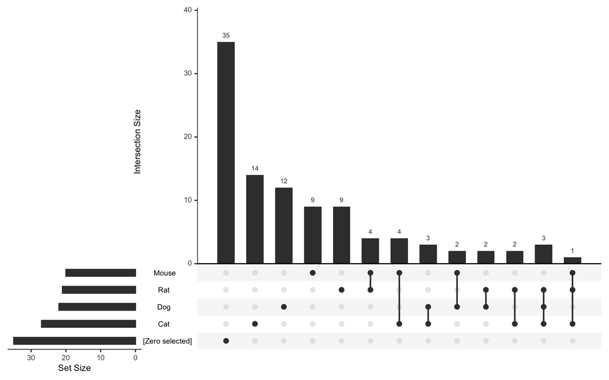

```r
checkbox_intersect(c1 %>% select(1:6), "checkbox", id.var = "id", add.zero = TRUE, tidy.labels = TRUE)
```

## 4.2 Repeating data - observation level

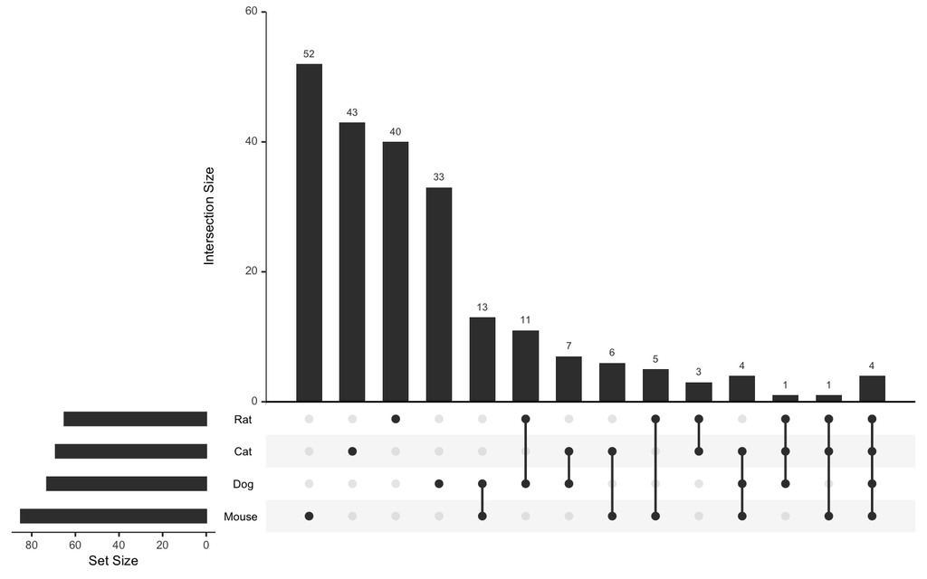

```r
checkbox_intersect(cb %>% select(1:7), "checkbox", id.var = "id", add.zero = FALSE, repeat.var = "rri")
```

## 4.3 Repeating data - record level

Excluding `repeat.var` with repeating data will greatly increase the number of intersections.

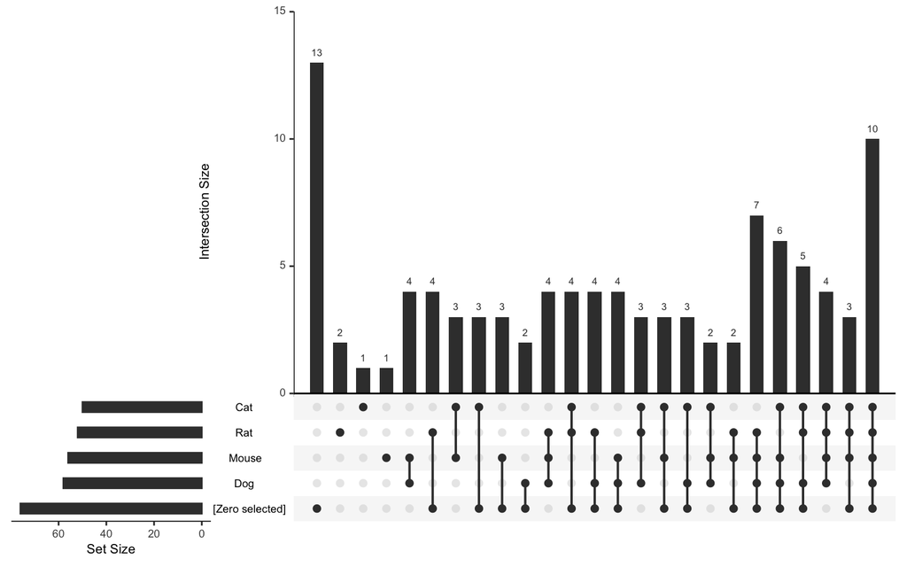

```r
checkbox_intersect(cb %>% select(1:7), "checkbox", id.var = "id", add.zero = TRUE)
```

# 5 Next steps

The above suite of functions could be the start of a new R package, but I’ve never made an R package. Here are my tentative next steps:

- Using ChatGPT to add error checking to functions
- ChatGPT can also take a decent stab at getting roxygen comments started
- `devtools::create("checkbox")` creates the requisite folders and files
- Need to reoranize .R file and then run `roxygen2::roxygenise()`
- Help files are created for each function

```r
# devtools::create("checkbox")
# roxygen2::roxygenise()

?lookup_names
```

```
## No documentation for 'lookup_names' in specified packages and libraries:
## you could try '??lookup_names'
```

```r
checkbox.by2(cb, "checkbox", id.vars = c("id"), by.var = "site", count = "all", byvar.reorder = c(1,3,2,4), add.zero = FALSE)

lookup_names(cb, selection = "checkbox")

#
# stats: only all none

cb %>% select(1, NULL) %>% left_join(., lp, by = c("id", "rri"))

cb %>% select(1, site, contains("checkbox")) %>%
  pivot_longer(., c(-id, -site), values_drop_na = TRUE) %>%
  select(value, site) %>% jgt(., order.cat = TRUE, by = "site", overall = TRUE)



checkbox_tally(cb, "checkbox", id.var = "id", by.var = "site", add.zero = TRUE,
               col.name = "Animal", spanner.size = 2, spanner.text = "Site" )

checkbox.upset2(cb, "checkbox", id.vars = c("id"))







checkbox_intersect(c1, "checkbox", id.var = "id", add.zero = TRUE)
checkbox_intersect(cb, "checkbox", id.var = "id", add.zero = TRUE, repeat.var = "rri")

tidy_labels(hd.cv, "tx_2")

lookup_names(hd.cv, "tx_2")


lookup_names(hd.cv, "tx_2", tidy.labels = TRUE)

data.frame(var = names(),
           input = formals(checkbox_gather) %>% paste()) %>%
  mutate(o = paste0(var, " = ", input, ", ")) %$% o

# ffun <- function(fun){
#   A <- deparse(substitute(fun))
#   b <- formals(fun)
#   C <- data.frame(var = names(b),
#            input = b %>% paste()) %>%
#   mutate(o = paste0(var, " = ", input, ", ")) %$% o
#
#   cat(A, "(",C, ")")
# }
#
# ffun(checkbox_gather)
#
# checkbox_gather( dat = ,  selection = ,  id.var = NULL,  by.var = NULL,  count = any,  tidy.labels = FALSE,  repeat.var = NULL,  stats = n,  toggle.names = TRUE,  simple.names = FALSE,  add.zero = FALSE,  output = df,  ... = ,  )

fun.fun <- function(fun){
a <- gsub("function ", deparse(substitute(fun)), paste(head(capture.output(args(fun)), -1), collapse = "\n" ))
cat(a)
}

fun.fun(jgt)
args(jgt)
# checkbox_gather(c1, selection = "checkbox", id.var = c("id"),
#                 stats = "only", toggle.names = FALSE, output = "summary")
# checkbox_gather(cb, selection = "checkbox", id.var = c("id"),
#                 by.var = "site",
#                  stats = "only", toggle.names = TRUE, output = "summary")
# checkbox_gather(cb, selection = "checkbox", id.var = c("id"),
#                 by.var = "site", repeat.var = "rri",
#                  stats = "only", toggle.names = TRUE, output = "summary")
```

```r
# cb_labels <- collect.labels(cb) %>% filter(grepl("checkbox", variable)) %>%
#   mutate(any = paste(label, "(any)"),
#          total = paste(label, "(total)"),
#          any_var = paste0("any_", variable),
#          total_var = paste0("total_", variable))
#
# lookup.any <- cb_labels$any_var
# names(lookup.any) <- cb_labels$any
# lookup.total <-   cb_labels$total_var
# names(lookup.total) <- cb_labels$total



# cb %>% group_by(id, site) %>%
#   summarise(across(contains("checkbox"), ~sum(!is.na(.x)), .names = "total_{.col}"),
#                                         n.obs =n()) %>%
#   rowwise() %>% mutate(across(contains("checkbox"), ~yesno(.x>0), .names = 'any{stringr::str_remove(.col, "total")}'),
#     n.selected = sum(across(contains("total"))),
#                        n.unique = sum(across(contains("total"))>0)) %>% ungroup() %>%
#   rename(any_of(c(lookup.any, lookup.total))) %>%
#   select(contains("total"), -id, site) %>%
#   jgt(., by = "site", overall = TRUE, one_row_binary = TRUE)
```

```r
A <- matrix(data = c(a = c(0, 1,1,1),
                b = c(-1,0,1,1),
                c = c(-1, -1, 0,1),
                d = c(-1, -1, -1, 0)),
       nrow = 4, byrow = TRUE)

A <- matrix(data = c(a = c(0, 1,1,1),
                b = c(0,0,1,1),
                c = c(0, 0, 0,1),
                d = c(0, 0, 0, 0)),
       nrow = 4, byrow = TRUE)

B <- matrix(data = c(a = c(0, 1,-1,1),
                b = c(-1,0,1,1),
                c = c(1, -1, 0,1),
                d = c(-1, -1, -1, 0)),
       nrow = 4, byrow = TRUE)

B <- matrix(data = c(a = c(0, 1,1,1),
                b = c(0,0,1,1),
                c = c(0, 0, 0,1),
                d = c(0, 0, 0, 0)),
       nrow = 4, byrow = TRUE)

rownames(A) <- colnames(A) <- c("a", "b", "c", "d")
# rownames(B) <- colnames(B) <- c("a", "b", "c", "d")

rownames(B) <-colnames(B) <- c("b", "e", "d", "f")


Vx <- expand.grid(unique(c(colnames(A), colnames(B))), unique(c(colnames(A), colnames(B)) ), stringsAsFactors = FALSE) %>%
  rename(item = Var1, name = Var2)


as.data.frame(A) %>% rownames_to_column() %>% pivot_longer(-1) %>%
  group_by(rowname) %>% summarise(v = sum(value))


comp1 <- left_join(Vx,
          bind_rows(as.data.frame(A) %>% rownames_to_column("item") %>% pivot_longer(-1),
          as.data.frame(B) %>% rownames_to_column("item") %>% pivot_longer(-1)),
          by = c("item", "name")) %>% distinct()

comp2 <- comp1 %>%
  arrange(item) %>% filter(value ==1) %>% select(name = item, comp = name)

comp3 <- full_join(comp1, comp2, by = "name") %>% distinct() %>% arrange(item)%>% filter(value == 1, !is.na(comp)) %>%
  select(item, name = comp, value)

bind_rows(comp1, comp3) %>%distinct() %>% arrange(item) %>%
  group_by(item, name) %>% summarise(value = sum(value, na.rm = TRUE)) %>%
  pivot_wider(., names_from = "name", values_from = "value", values_fill = NA)
```

```r
A %*% t(A) %*% matrix(data = c(1, 1,1,1),nrow = 4, byrow = TRUE)

B <- matrix(data = c(a = c(0, 1,1,1, 0, 0),
                b = c(0,0,1,1, 1, 1),
                c = c(0, 0, 0,1, 0, 0),
                d = c(0, 0, 0, 0, 0, 1),
                e = c(0, 0, 0, 1, 0, 1),
                f = c(0, 0, 0, 0, 0, 0)),
       nrow = 6, byrow = TRUE)

C <- matrix(data = c(a = c(1, 1,1,1, 0, 0),
                b = c(1,1,1,1, 1, 1),
                c = c(1, 1, 1,1, 0, 0),
                d = c(1,1,1,1, 1, 1),
                e = c(0, 1, 0, 1, 1, 1),
                f = c(0, 1, 0, 1, 1, 1)),
       nrow = 6, byrow = TRUE)

colnames(B) <- c("a", "b", "c", "d", "e", "f")
rownames(B) <- c("a", "b", "c", "d", "e", "f")

B %*% t(B) %*% matrix(data = c(1, 1,1,1, 1, 1),ncol = 1, byrow = TRUE)
B %*% t(B) %*% matrix(data = c(1, .5,1,.5, 1, 1),ncol = 1, byrow = TRUE)

B %*% t(B) %*%(diag(c(4,1,4, 1, 4,4), 6 )*0.5) %*% matrix(data = c(1, 1,1,1, 1, 1),ncol = 1, byrow = TRUE)
```

```r
`%>>%` <- function(a, b){
  if(!is.data.frame(a)){
  RE <- data.frame(item = a, item2 = b)
  }else{
   nr <- nrow(a) + 1
    RE <- bind_rows(a, data.frame(item = c(a$item, a$item2[nrow(a)]), item2 = rep(b, nr))) %>% distinct()
  }

  return(RE)
}
"A" %>>% "B" %>>% "C"
g <- "A" %>>% "B" %>>% "I" %>>% "E"
h <- "B" %>>% "C"
hh <- "C" %>>% "D"
h2 <- "D" %>>% "E"
h3 <- "E" %>>% "F"
h4 <- "F" %>>% "G"
h5 <- "G" %>>% "H"
H <- bind_rows(g, h, hh, h2, h3, h4, h5)

k <- bind_rows(H %>% mutate(value =1),
data.frame(item = H$item2, item2 = H$item) %>% mutate(value = -1)) %>%
  distinct()

left_join(k, k %>% rename(item2 = item, comp = item2), by = c("item2", "value") ) %>% distinct() %>%
  filter(item != comp|is.na(comp)) %>%
  pivot_longer(., -c("item", "value"), names_to = "x", values_to = "item2", values_drop_na = TRUE) %>%
  select(-x)%>% distinct() %>%
  mutate(item = fct_reorder(item, value, sum)) %>%
  mutate(item2 = factor(item2, levels = levels(item))) %>%
  arrange(desc(item), desc(item2) ) %>%
  pivot_wider(., names_from = "item2", values_from = "value") %>%
  select(item, all_of(rev(levels(.$item))))
```

```r
k <- bind_rows(H %>% mutate(value =1),
data.frame(item = H$item2, item2 = H$item) %>% mutate(value = -1)) %>%
  distinct() %>% mutate(n =1)

i <- 0
j<- 100
round <- 0
while(i < j){
  i <- nrow(k)
    round <- round+1

  k2 <- left_join(k %>% select(-n),
                  k %>% select(-n) %>% rename(item2 = item, comp = item2),
                  by = c("item2", "value") ) %>%
    distinct() %>%
  filter(item != comp|is.na(comp)) %>%
  pivot_longer(., -c("item", "value"), names_to = "x", values_to = "item2", values_drop_na = TRUE) %>%
  select(-x)%>% distinct()

  k <- full_join(k, k2, c("item", "item2", "value")) %>% mutate(n = replace_na(n, round))

  j <- nrow(k)

}

k %>% select(-n) %>%
  mutate(item = fct_reorder(item, value, sum)) %>%
  mutate(item2 = factor(item2, levels = levels(item))) %>%
  arrange(desc(item), desc(item2) ) %>%
  pivot_wider(., names_from = "item2", values_from = "value") %>%
  select(item, all_of(rev(levels(.$item))))
```

```r
k <- bind_rows(j %>% mutate(value =1),
data.frame(item = j$name, name = j$item) %>% mutate(value = -1)) %>%
  group_by(item, name) %>% summarise(value = sum(value))

left_join(k, k %>% rename(name = item, comp = name), by = c("name", "value") ) %>% distinct() %>%
  filter(item != comp|is.na(comp)) %>%
  pivot_longer(., -c("item", "value"), names_to = "x", values_to = "item2", values_drop_na = TRUE) %>%
  select(-x)%>%
  group_by(item, item2) %>% summarise(value = sum(value)) %>%
  mutate(item = fct_reorder(item, value, sum)) %>%
  mutate(item2 = factor(item2, levels = levels(item))) %>%
  arrange((item), desc(item2) ) %>%
  pivot_wider(., names_from = "item2", values_from = "value") %>%
  select(item, all_of(levels(.$item)))
```